# Project: TMDb Data Investigation

- Introduction
- Data Wrangling
- Exploratory Data Analysis
- Conclusions

## Overview

### This file contains the data analysis for (TMDb), including analysis on the highest grossing movies, top year in which movies were produced, and more. Throughtout the project, we will be answering the below question: -

Average movies' runtime of all time

Top 5 movies in terms of profit.

Has the number of movie releases changed over the years?

which film director produced the most movies, and how many did they make?

which movie has the highest average score?

correlation between the data.

```python
# Use this cell to set up import statements for all of the packages that you
#   plan to use.
import pandas as pd
import numpy as np
import matplotlib.pyplot as plt
import seaborn as sns
%matplotlib inline
# Remember to include a 'magic word' so that your visualizations are plotted
#   inline with the notebook. See this page for more:
#   http://ipython.readthedocs.io/en/stable/interactive/magics.html
```

## Data Wrangling

```python
# Load your data and print out a few lines. Perform operations to inspect data
#   types and look for instances of missing or possibly errant data.
df=pd.read_csv('tmdb-movies.csv')
```

```python
df.head()
```

|  | id | imdb_id | popularity | budget | revenue | original_title | cast | homepage | director | tagline | ... | overview | runtime | genres | production_companies | release_date | vote_count | vote_average | release_year | budget_adj | revenue_adj |
| --- | --- | --- | --- | --- | --- | --- | --- | --- | --- | --- | --- | --- | --- | --- | --- | --- | --- | --- | --- | --- | --- |
| 0 | 135397 | tt0369610 | 32.985763 | 150000000 | 1513528810 | Jurassic World | Chris Pratt\|Bryce Dallas Howard\|Irrfan Khan\|Vi... | http://www.jurassicworld.com/ | Colin Trevorrow | The park is open. | ... | Twenty-two years after the events of Jurassic ... | 124 | Action\|Adventure\|Science Fiction\|Thriller | Universal Studios\|Amblin Entertainment\|Legenda... | 6/9/15 | 5562 | 6.5 | 2015 | 1.379999e+08 | 1.392446e+09 |
| 1 | 76341 | tt1392190 | 28.419936 | 150000000 | 378436354 | Mad Max: Fury Road | Tom Hardy\|Charlize Theron\|Hugh Keays-Byrne\|Nic... | http://www.madmaxmovie.com/ | George Miller | What a Lovely Day. | ... | An apocalyptic story set in the furthest reach... | 120 | Action\|Adventure\|Science Fiction\|Thriller | Village Roadshow Pictures\|Kennedy Miller Produ... | 5/13/15 | 6185 | 7.1 | 2015 | 1.379999e+08 | 3.481613e+08 |
| 2 | 262500 | tt2908446 | 13.112507 | 110000000 | 295238201 | Insurgent | Shailene Woodley\|Theo James\|Kate Winslet\|Ansel... | http://www.thedivergentseries.movie/#insurgent | Robert Schwentke | One Choice Can Destroy You | ... | Beatrice Prior must confront her inner demons ... | 119 | Adventure\|Science Fiction\|Thriller | Summit Entertainment\|Mandeville Films\|Red Wago... | 3/18/15 | 2480 | 6.3 | 2015 | 1.012000e+08 | 2.716190e+08 |
| 3 | 140607 | tt2488496 | 11.173104 | 200000000 | 2068178225 | Star Wars: The Force Awakens | Harrison Ford\|Mark Hamill\|Carrie Fisher\|Adam D... | http://www.starwars.com/films/star-wars-episod... | J.J. Abrams | Every generation has a story. | ... | Thirty years after defeating the Galactic Empi... | 136 | Action\|Adventure\|Science Fiction\|Fantasy | Lucasfilm\|Truenorth Productions\|Bad Robot | 12/15/15 | 5292 | 7.5 | 2015 | 1.839999e+08 | 1.902723e+09 |
| 4 | 168259 | tt2820852 | 9.335014 | 190000000 | 1506249360 | Furious 7 | Vin Diesel\|Paul Walker\|Jason Statham\|Michelle ... | http://www.furious7.com/ | James Wan | Vengeance Hits Home | ... | Deckard Shaw seeks revenge against Dominic Tor... | 137 | Action\|Crime\|Thriller | Universal Pictures\|Original Film\|Media Rights ... | 4/1/15 | 2947 | 7.3 | 2015 | 1.747999e+08 | 1.385749e+09 |

5 rows × 21 columns

```python
# Check the name of the columns for a better visibilty
df.columns
```

```
Index(['id', 'imdb_id', 'popularity', 'budget', 'revenue', 'original_title',
       'cast', 'homepage', 'director', 'tagline', 'keywords', 'overview',
       'runtime', 'genres', 'production_companies', 'release_date',
       'vote_count', 'vote_average', 'release_year', 'budget_adj',
       'revenue_adj'],
      dtype='object')
```

```python
#getting info about the DF
df.info()
```

```
<class 'pandas.core.frame.DataFrame'>
RangeIndex: 10866 entries, 0 to 10865
Data columns (total 21 columns):
 #   Column                Non-Null Count  Dtype
---  ------                --------------  -----
 0   id                    10866 non-null  int64
 1   imdb_id               10856 non-null  object
 2   popularity            10866 non-null  float64
 3   budget                10866 non-null  int64
 4   revenue               10866 non-null  int64
 5   original_title        10866 non-null  object
 6   cast                  10790 non-null  object
 7   homepage              2936 non-null   object
 8   director              10822 non-null  object
 9   tagline               8042 non-null   object
 10  keywords              9373 non-null   object
 11  overview              10862 non-null  object
 12  runtime               10866 non-null  int64
 13  genres                10843 non-null  object
 14  production_companies  9836 non-null   object
 15  release_date          10866 non-null  object
 16  vote_count            10866 non-null  int64
 17  vote_average          10866 non-null  float64
 18  release_year          10866 non-null  int64
 19  budget_adj            10866 non-null  float64
 20  revenue_adj           10866 non-null  float64
dtypes: float64(4), int64(6), object(11)
memory usage: 1.7+ MB
```

```python
df.shape
```

```
(10866, 21)
```

```python
# Filter the data by dropping the columns which won't be used in the analysis
df.drop(['imdb_id','cast','tagline','overview','keywords','budget_adj','revenue_adj', 'production_companies', 'homepage'], axis = 1, inplace = True)
```

```python
df.head()
```

|  | id | popularity | budget | revenue | original_title | director | runtime | genres | release_date | vote_count | vote_average | release_year |
| --- | --- | --- | --- | --- | --- | --- | --- | --- | --- | --- | --- | --- |
| 0 | 135397 | 32.985763 | 150000000 | 1513528810 | Jurassic World | Colin Trevorrow | 124 | Action\|Adventure\|Science Fiction\|Thriller | 6/9/15 | 5562 | 6.5 | 2015 |
| 1 | 76341 | 28.419936 | 150000000 | 378436354 | Mad Max: Fury Road | George Miller | 120 | Action\|Adventure\|Science Fiction\|Thriller | 5/13/15 | 6185 | 7.1 | 2015 |
| 2 | 262500 | 13.112507 | 110000000 | 295238201 | Insurgent | Robert Schwentke | 119 | Adventure\|Science Fiction\|Thriller | 3/18/15 | 2480 | 6.3 | 2015 |
| 3 | 140607 | 11.173104 | 200000000 | 2068178225 | Star Wars: The Force Awakens | J.J. Abrams | 136 | Action\|Adventure\|Science Fiction\|Fantasy | 12/15/15 | 5292 | 7.5 | 2015 |
| 4 | 168259 | 9.335014 | 190000000 | 1506249360 | Furious 7 | James Wan | 137 | Action\|Crime\|Thriller | 4/1/15 | 2947 | 7.3 | 2015 |

```python
#getting info about the DF post dropping columns
df.shape
```

```
(10866, 12)
```

```python
df.info()
```

```
<class 'pandas.core.frame.DataFrame'>
RangeIndex: 10866 entries, 0 to 10865
Data columns (total 12 columns):
 #   Column          Non-Null Count  Dtype
---  ------          --------------  -----
 0   id              10866 non-null  int64
 1   popularity      10866 non-null  float64
 2   budget          10866 non-null  int64
 3   revenue         10866 non-null  int64
 4   original_title  10866 non-null  object
 5   director        10822 non-null  object
 6   runtime         10866 non-null  int64
 7   genres          10843 non-null  object
 8   release_date    10866 non-null  object
 9   vote_count      10866 non-null  int64
 10  vote_average    10866 non-null  float64
 11  release_year    10866 non-null  int64
dtypes: float64(2), int64(6), object(4)
memory usage: 1018.8+ KB
```

```python
df.isnull().sum()
```

```
id                 0
popularity         0
budget             0
revenue            0
original_title     0
director          44
runtime            0
genres            23
release_date       0
vote_count         0
vote_average       0
release_year       0
dtype: int64
```

```python
# checking and dropping duplicates
df.duplicated().sum()
```

```
1
```

```python
df.drop_duplicates(inplace = True)
```

```python
df.shape
```

```
(10865, 12)
```

```python
# Ready to analyze the data
df.describe()
```

|  | id | popularity | budget | revenue | runtime | vote_count | vote_average | release_year |
| --- | --- | --- | --- | --- | --- | --- | --- | --- |
| count | 10865.000000 | 10865.000000 | 1.086500e+04 | 1.086500e+04 | 10865.000000 | 10865.000000 | 10865.000000 | 10865.000000 |
| mean | 66066.374413 | 0.646446 | 1.462429e+07 | 3.982690e+07 | 102.071790 | 217.399632 | 5.975012 | 2001.321859 |
| std | 92134.091971 | 1.000231 | 3.091428e+07 | 1.170083e+08 | 31.382701 | 575.644627 | 0.935138 | 12.813260 |
| min | 5.000000 | 0.000065 | 0.000000e+00 | 0.000000e+00 | 0.000000 | 10.000000 | 1.500000 | 1960.000000 |
| 25% | 10596.000000 | 0.207575 | 0.000000e+00 | 0.000000e+00 | 90.000000 | 17.000000 | 5.400000 | 1995.000000 |
| 50% | 20662.000000 | 0.383831 | 0.000000e+00 | 0.000000e+00 | 99.000000 | 38.000000 | 6.000000 | 2006.000000 |
| 75% | 75612.000000 | 0.713857 | 1.500000e+07 | 2.400000e+07 | 111.000000 | 146.000000 | 6.600000 | 2011.000000 |
| max | 417859.000000 | 32.985763 | 4.250000e+08 | 2.781506e+09 | 900.000000 | 9767.000000 | 9.200000 | 2015.000000 |

# At the previous phase, we cleaned up the data and made it ready to be investigated

## Steps followed are as following;

Loading data

Getting the shape and info of our dataframe

Dropping the unnecessary columns

Removing duplicates

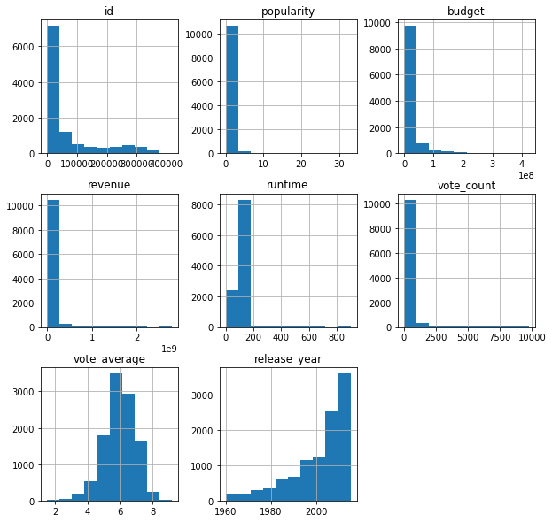

```python
# Use this, and more code cells, to explore your data. Don't forget to add
#   Markdown cells to document your observations and findings.
df.hist(figsize = (10,10));
```

## Exploratory Data Analysis

# 1- What is the average runtime of the movies?

```python
df['runtime'].mean()
```

```
102.07179015186378
```

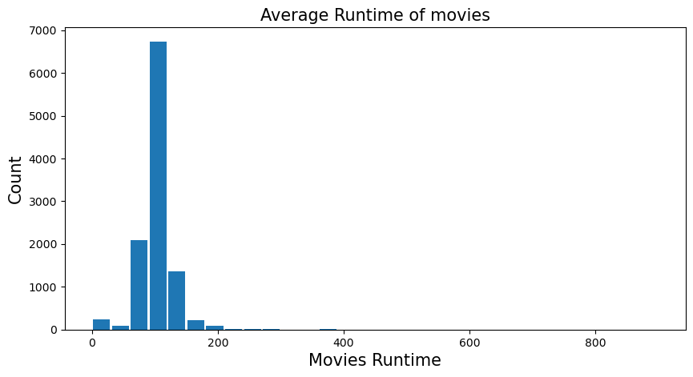

```python
plt.figure(figsize=(10,5), dpi = 100)

plt.xlabel('Movies Runtime', fontsize = 15)
plt.ylabel('Count', fontsize=15)
plt.title('Average Runtime of movies', fontsize=15)

plt.hist(df['runtime'], rwidth = 0.9, bins =30)
plt.show()
```

## As showing above, the average movies' runtime of all times is 102 minutes

# 2- A- What is the most profitable movie?

### 2- B- Also mentioning the top 5 movies in profit

```python
#creating a new column for the profit
df['profit']= df['revenue'] - df['budget']
```

```python
# rearraning columns
df=df[['id', 'original_title', 'budget', 'revenue', 'profit',
       'director', 'runtime', 'genres', 'release_date',
       'vote_count', 'vote_average', 'release_year', 'popularity']]
```

```python
#As instructed in the previous review, creating a function to get the most profitable movie
def highest (column):
    #highest data
    most= df[column].idxmax()
    highest_data=pd.DataFrame(df.loc[most])

    return highest_data
highest('profit')
```

|  | 1386 |
| --- | --- |
| id | 19995 |
| original_title | Avatar |
| budget | 237000000 |
| revenue | 2781505847 |
| profit | 2544505847 |
| director | James Cameron |
| runtime | 162 |
| genres | Action\|Adventure\|Fantasy\|Science Fiction |
| release_date | 12/10/09 |
| vote_count | 8458 |
| vote_average | 7.1 |
| release_year | 2009 |
| popularity | 9.43277 |

```python
#As instructed in the previous review, creating a function to get the lowest profitable movie
def lowest (column):
    #lowest data
    lowest= df[column].idxmin()
    lowest_data=pd.DataFrame(df.loc[lowest])

    return lowest_data
lowest('profit')
```

|  | 2244 |
| --- | --- |
| id | 46528 |
| original_title | The Warrior's Way |
| budget | 425000000 |
| revenue | 11087569 |
| profit | -413912431 |
| director | Sngmoo Lee |
| runtime | 100 |
| genres | Adventure\|Fantasy\|Action\|Western\|Thriller |
| release_date | 12/2/10 |
| vote_count | 74 |
| vote_average | 6.4 |
| release_year | 2010 |
| popularity | 0.25054 |

## As showing above, **Avatar** comes in as the most profitable movies while **The Warrior's Way** comes as the lowest earned profit.

```python
def top_n (n,column):
    x = df[['original_title', column]].sort_values(column, ascending = False).head(n)
    return x
top_5 = top_n (5,'profit')
```

```python
#setting up the range for the plot bar
arr= np.arange(len(top_5.original_title))
arr
```

```
array([0, 1, 2, 3, 4])
```

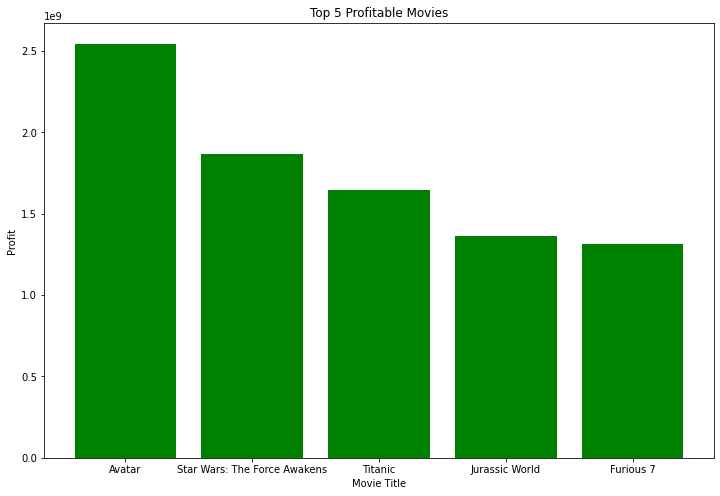

```python
plt.figure(figsize = (12,8))
plt.bar(arr,top_5.profit, color = 'Green')
plt.xticks(arr,top_5.original_title)
plt.xlabel('Movie Title')
plt.ylabel('Profit')
plt.title('Top 5 Profitable Movies')
plt.show()
```

## The above graph is showing the top 5 movies in terms of profit

# 3- Has the number of movie releases changed over the years?

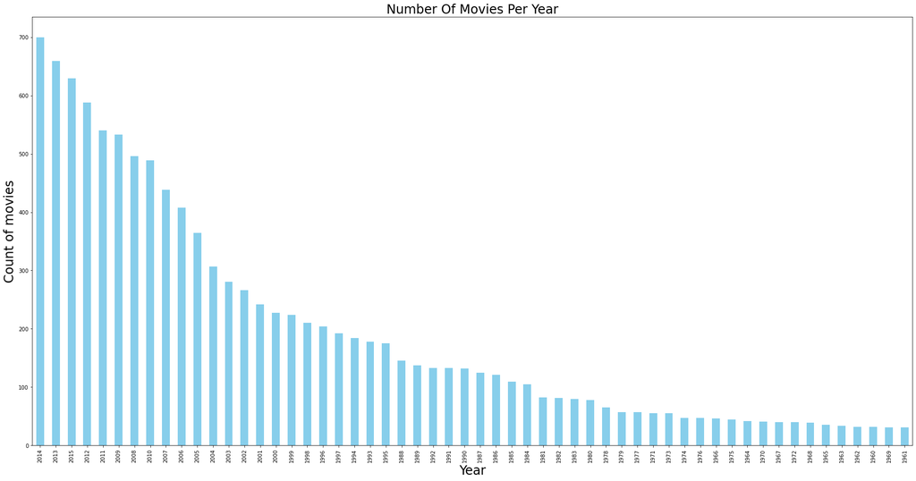

```python
plt.figure(figsize = (30,15))
df['release_year'].value_counts().plot.bar(color = 'skyblue')
plt.title('Number Of Movies Per Year', fontsize = 24)
plt.xlabel('Year', fontsize=24)
plt.ylabel('Count of movies', fontsize=24)
plt.show()
```

```python
# The year with most released movies
def most_released (column):
    info = df[column].value_counts()[df[column].value_counts() == df[column].value_counts().max()]
    return info
most_released ("release_year")
```

```
2014    700
Name: release_year, dtype: int64
```

# 4- Which film director produced the most movies, and how many did they make?

```python
# The director with most released movies
most_released ("director")
```

```
Woody Allen    45
Name: director, dtype: int64
```

# 5- Which movie has the highest average score?

```python
#Movie with the highest average score
highest('vote_average')
```

|  | 3894 |
| --- | --- |
| id | 125336 |
| original_title | The Story of Film: An Odyssey |
| budget | 0 |
| revenue | 0 |
| profit | 0 |
| director | Mark Cousins |
| runtime | 900 |
| genres | Documentary |
| release_date | 9/3/11 |
| vote_count | 14 |
| vote_average | 9.2 |
| release_year | 2011 |
| popularity | 0.006925 |

```python
#Movie with the lowest average score
lowest('vote_average')
```

|  | 7772 |
| --- | --- |
| id | 25055 |
| original_title | Transmorphers |
| budget | 0 |
| revenue | 0 |
| profit | 0 |
| director | Leigh Scott |
| runtime | 86 |
| genres | Action\|Adventure\|Science Fiction |
| release_date | 6/26/07 |
| vote_count | 10 |
| vote_average | 1.5 |
| release_year | 2007 |
| popularity | 0.12112 |

## Calulating top 10 movies in terms of Average Vote score

```python
#setting up the data to get the top 10 moviest with highest average score
top_10_va = top_n (10, 'vote_average')
```

```python
#setting up the range for the plot bar
arr= np.arange(len(top_10_va.original_title))
arr
```

```
array([0, 1, 2, 3, 4, 5, 6, 7, 8, 9])
```

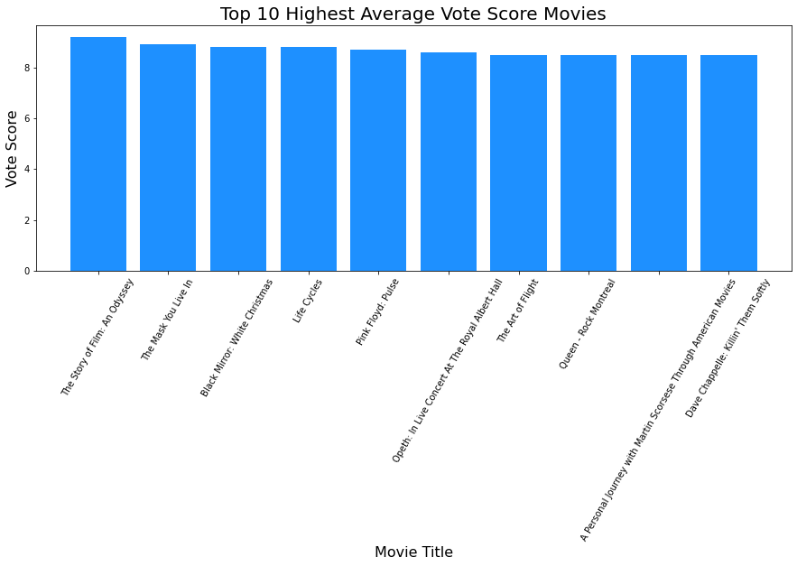

```python
plt.figure(figsize = (15,5))
plt.bar(arr,top_10_va.vote_average, color = 'dodgerblue')
plt.xticks(arr,top_10_va.original_title)
plt.xlabel('Movie Title', fontsize = 16)
plt.ylabel('Vote Score', fontsize = 16)
plt.title('Top 10 Highest Average Vote Score Movies',fontsize = 20)
plt.xticks(rotation = 60)
plt.show()
```

## The movie with highest average vote score is **The Story of Film: An Odyssey**

# 6- Getting the coorelation between the data

|  | id | budget | revenue | profit | runtime | vote_count | vote_average | release_year | popularity |
| --- | --- | --- | --- | --- | --- | --- | --- | --- | --- |
| id | 1.000000 | -0.141341 | -0.099235 | -0.074975 | -0.088368 | -0.035555 | -0.058391 | 0.511393 | -0.014351 |
| budget | -0.141341 | 1.000000 | 0.734928 | 0.570222 | 0.191300 | 0.632719 | 0.081067 | 0.115904 | 0.545481 |
| revenue | -0.099235 | 0.734928 | 1.000000 | 0.976162 | 0.162830 | 0.791174 | 0.172541 | 0.057070 | 0.663360 |
| profit | -0.074975 | 0.570222 | 0.976162 | 1.000000 | 0.136022 | 0.755908 | 0.183067 | 0.032038 | 0.628997 |
| runtime | -0.088368 | 0.191300 | 0.162830 | 0.136022 | 1.000000 | 0.163273 | 0.156813 | -0.117187 | 0.139032 |
| vote_count | -0.035555 | 0.632719 | 0.791174 | 0.755908 | 0.163273 | 1.000000 | 0.253818 | 0.107962 | 0.800828 |
| vote_average | -0.058391 | 0.081067 | 0.172541 | 0.183067 | 0.156813 | 0.253818 | 1.000000 | -0.117576 | 0.209517 |
| release_year | 0.511393 | 0.115904 | 0.057070 | 0.032038 | -0.117187 | 0.107962 | -0.117576 | 1.000000 | 0.089806 |
| popularity | -0.014351 | 0.545481 | 0.663360 | 0.628997 | 0.139032 | 0.800828 | 0.209517 | 0.089806 | 1.000000 |

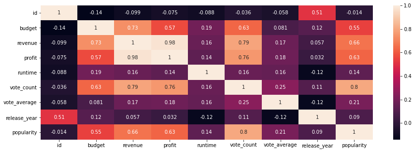

```python
#get the correlation between the data
plt.figure(figsize=(15,5))
corrMatrix = df.corr()
sns.heatmap(corrMatrix, annot=True)
corrMatrix
```

## As showing in the correlation matrix above, post adding the profit column, we conculde that there are many attributes with positive correlation

For instance, the Profit has a high postive correlation with vote counts, which means the higher the counts the more the expected profit. Also, Similar to the above, popularity has a postive correlation with vote counts, indicating that the more popular the movie, the higher the vote counts will be.

```python
df.to_csv('tmdb-movies.csv')
```

# Conclusions

### **Avatar** is the highest profitable movie produced

### Top director with highest number of movies produced is: **Woody Allen** wih a total produced films of *45*

### Top year in which films were made is **2014** with a total of *700* movies produced

### The movie with highest average score is **The Story of Film: An Odyssey** with a total average vote score of *9.2*

## Limitation

We have used TMDb Movies dataset for our analysis and worked with popularity, revenue and runtime.

Our analysis is limited to only the provided dataset. For example, the dataset does not confirm that every release of every director is listed.

There is no normalization or exchange rate or currency conversion is considered during this analysis and our analysis is limited to the numerical values of revenue.

Dropping missing or Null values from variables of our interest might skew our analysis and could show unintentional bias towards the relationship being analyzed. etc.